# MSDS 6306: Doing Data Science - Case Study 02

Banu

2023-04-07

## R Markdown for Case Study 02

DDSAnalytics is an analytics company that specializes in talent management solutions for Fortune 100 companies. Talent management is defined as the iterative process of developing and retaining employees. It may include workforce planning, employee training programs, identifying high-potential employees and reducing/preventing voluntary employee turnover (attrition). To gain a competitive edge over its competition, DDSAnalytics is planning to leverage data science for talent management. The executive leadership has identified predicting employee turnover as its first application of data science for talent management. Before the business green lights the project, they have tasked your data science team to conduct an analysis of existing employee data.

You have been given a dataset (CaseStudy2-data.csv on AWS S3 in the ddsproject1 bucket) to do a data analysis to identify factors that lead to attrition. You should identify the top three factors that contribute to turnover (backed up by evidence provided by analysis). There may or may not be a need to create derived attributes/variables/features. The business is also interested in learning about any job role specific trends that may exist in the data set (e.g., “Data Scientists have the highest job satisfaction”). You can also provide any other interesting trends and observations from your analysis. The analysis should be backed up by robust experimentation and appropriate visualization. Experiments and analysis must be conducted in R. You will also be asked to build a model to predict attrition.

#include all Libraries required for the EDA

```r
library(class)
library(caret)
```

```r
library(e1071)
library(naniar)
library(ggplot2)
library(GGally)
library(dplyr)
library(stringr)
library(tidyverse)
library(plotly)
```

#Read the Case Study 2 files in csv format

```r
CS2 = read.csv("/Users/Banu/Documents/MSDS/Unit 14 and 15 Case Study 2/CaseStudy2-data.csv")

CS2Test1 = read.csv("/Users/Banu/Documents/MSDS/Unit 14 and 15 Case Study 2/CaseStudy2CompSet No Attrition.csv")
```

#Review for any missing values

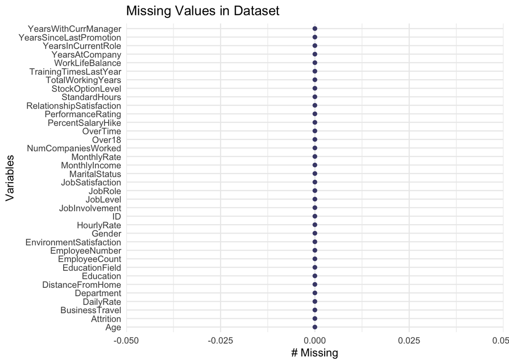

```r
gg_miss_var(CS2) + ggtitle("Missing Values in Dataset")
```

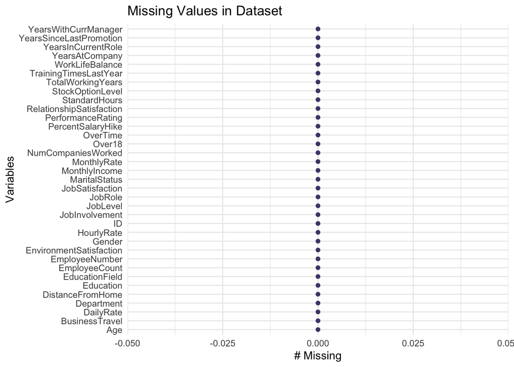

```r
gg_miss_var(CS2Test1) + ggtitle("Missing Values in Dataset")
```

#describe the datasets - Number of Row and Columns

```r
dim(CS2)
```

```
## [1] 870  36
```

```r
dim(CS2Test1)
```

```
## [1] 300  35
```

#describe the dataset’s columns

```r
str(CS2)
```

```
## 'data.frame':    870 obs. of  36 variables:
##  $ ID                      : int  1 2 3 4 5 6 7 8 9 10 ...
##  $ Age                     : int  32 40 35 32 24 27 41 37 34 34 ...
##  $ Attrition               : chr  "No" "No" "No" "No" ...
##  $ BusinessTravel          : chr  "Travel_Rarely" "Travel_Rarely" "Travel_Frequently" "Travel_Rarely" ...
##  $ DailyRate               : int  117 1308 200 801 567 294 1283 309 1333 653 ...
##  $ Department              : chr  "Sales" "Research & Development" "Research & Development" "Sales" ...
##  $ DistanceFromHome        : int  13 14 18 1 2 10 5 10 10 10 ...
##  $ Education               : int  4 3 2 4 1 2 5 4 4 4 ...
##  $ EducationField          : chr  "Life Sciences" "Medical" "Life Sciences" "Marketing" ...
##  $ EmployeeCount           : int  1 1 1 1 1 1 1 1 1 1 ...
##  $ EmployeeNumber          : int  859 1128 1412 2016 1646 733 1448 1105 1055 1597 ...
##  $ EnvironmentSatisfaction : int  2 3 3 3 1 4 2 4 3 4 ...
##  $ Gender                  : chr  "Male" "Male" "Male" "Female" ...
##  $ HourlyRate              : int  73 44 60 48 32 32 90 88 87 92 ...
```

[output cut: 22 more lines]

```r
str(CS2Test1)
```

```
## 'data.frame':    300 obs. of  35 variables:
##  $ ID                      : int  1171 1172 1173 1174 1175 1176 1177 1178 1179 1180 ...
##  $ Age                     : int  35 33 26 55 29 51 52 39 31 31 ...
##  $ BusinessTravel          : chr  "Travel_Rarely" "Travel_Rarely" "Travel_Rarely" "Travel_Rarely" ...
##  $ DailyRate               : int  750 147 1330 1311 1246 1456 585 1387 1062 534 ...
##  $ Department              : chr  "Research & Development" "Human Resources" "Research & Development" "Research & Development" ...
##  $ DistanceFromHome        : int  28 2 21 2 19 1 29 10 24 20 ...
##  $ Education               : int  3 3 3 3 3 4 4 5 3 3 ...
##  $ EducationField          : chr  "Life Sciences" "Human Resources" "Medical" "Life Sciences" ...
##  $ EmployeeCount           : int  1 1 1 1 1 1 1 1 1 1 ...
##  $ EmployeeNumber          : int  1596 1207 1107 505 1497 145 2019 1618 1252 587 ...
##  $ EnvironmentSatisfaction : int  2 2 1 3 3 1 1 2 3 1 ...
##  $ Gender                  : chr  "Male" "Male" "Male" "Female" ...
##  $ HourlyRate              : int  46 99 37 97 77 30 40 76 96 66 ...
##  $ JobInvolvement          : int  4 3 3 3 2 2 3 3 2 3 ...
```

[output cut: 21 more lines]

#Our Objective is to predict attrition, so with the given dataset, let’s see how response variable Attrition behaves with respect to other explanotary variables

#Plotting Attrition by Age

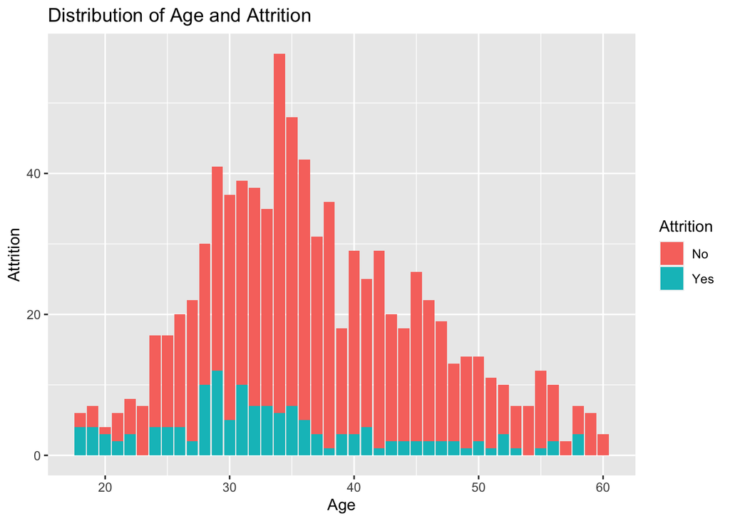

```r
CS2 %>%  ggplot(aes(x = Age, fill = Attrition)) + geom_bar() + ggtitle("Distribution of Age and Attrition") + ylab("Attrition")
```

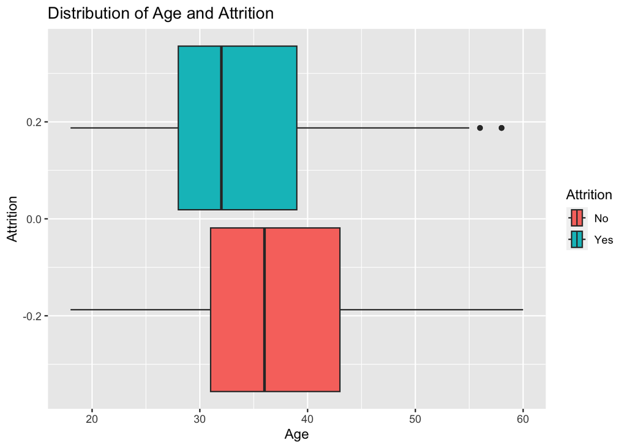

```r
CS2 %>%  ggplot(aes(x = Age, fill = Attrition)) + geom_boxplot() + ggtitle("Distribution of Age and Attrition") + ylab("Attrition")
```

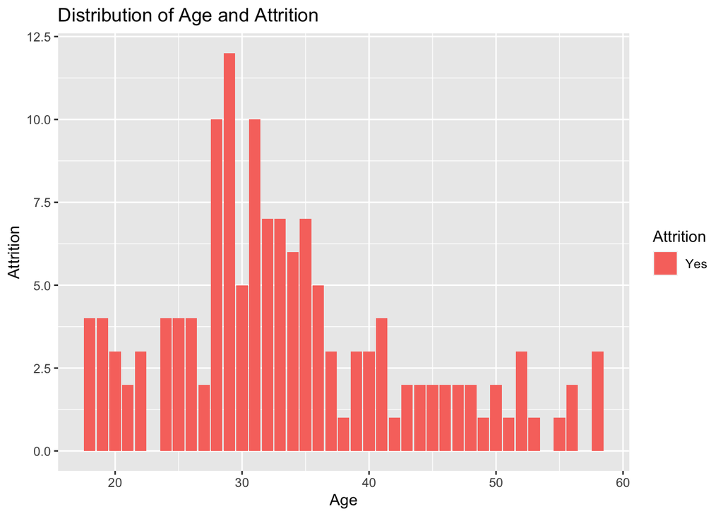

```r
CS2 %>% filter(Attrition == "Yes") %>% ggplot(aes(x = Age, fill = Attrition)) + geom_bar() + ggtitle("Distribution of Age and Attrition") + ylab("Attrition")
```

#Plotting Attrition by DistanceFromHome

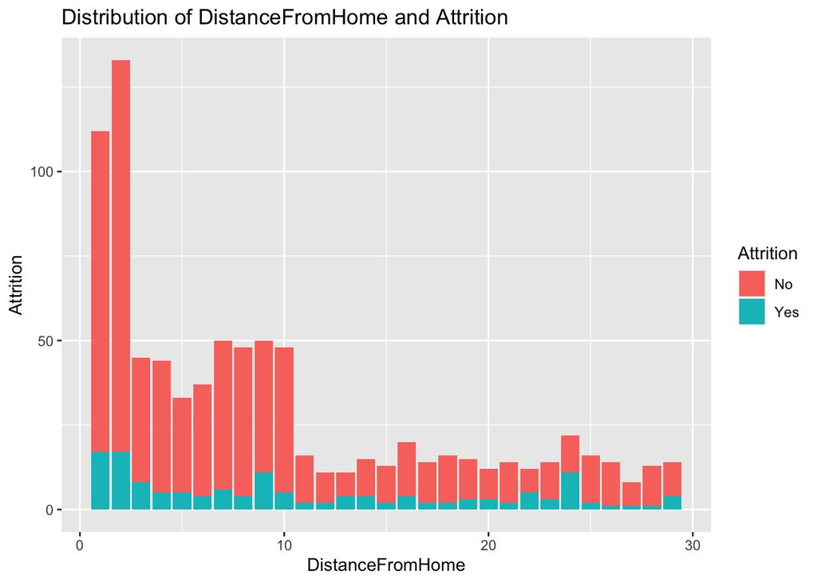

```r
CS2 %>%  ggplot(aes(x = DistanceFromHome, fill = Attrition)) + geom_bar() + ggtitle("Distribution of DistanceFromHome and Attrition") + ylab("Attrition")
```

#Looking at the plot, Distance From Home is not significant in determining Attrition,

#Plotting Attrition by Daily, Hourly, Monthly Rate and Monthly Income

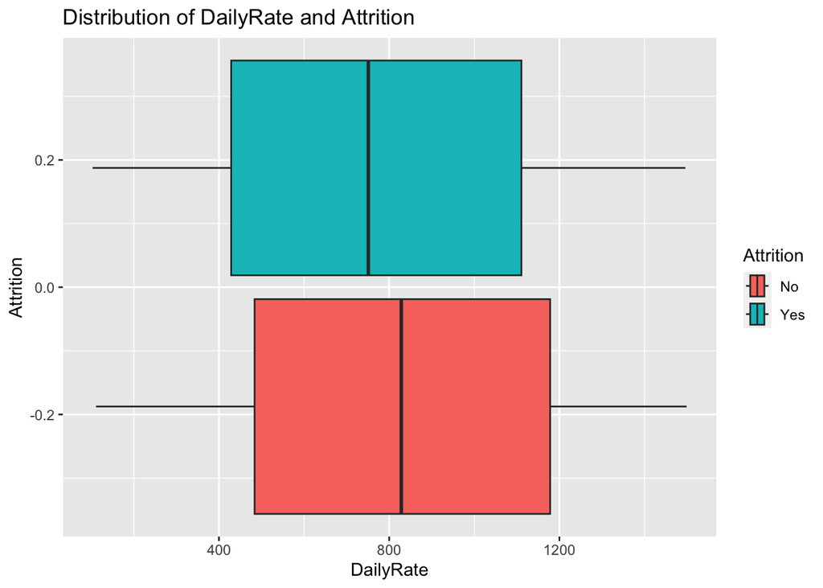

```r
CS2 %>%  ggplot(aes(x = DailyRate, fill = Attrition)) + geom_boxplot() + ggtitle("Distribution of DailyRate and Attrition") + ylab("Attrition")
```

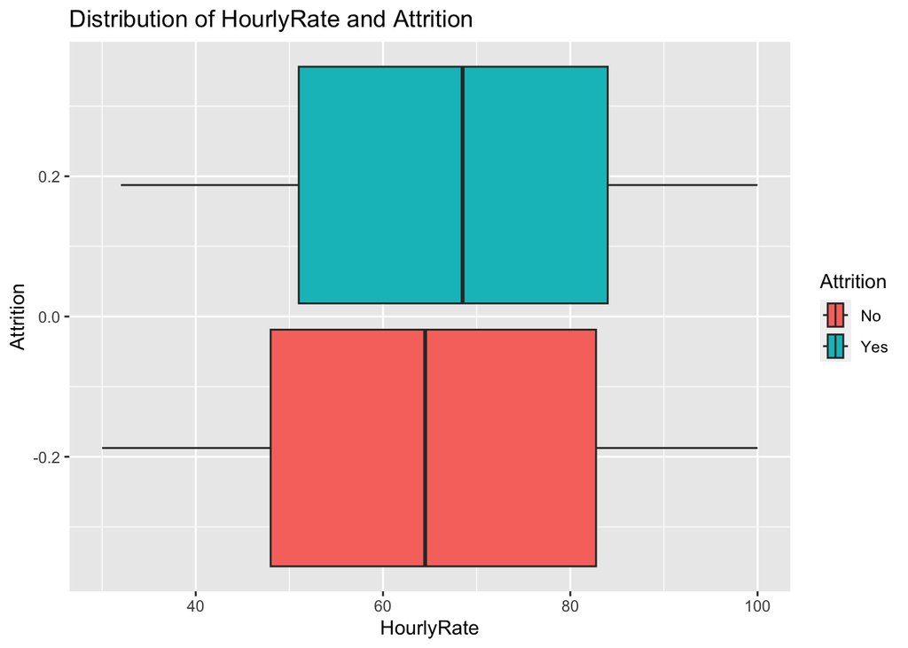

```r
CS2 %>%  ggplot(aes(x = HourlyRate, fill = Attrition)) + geom_boxplot() + ggtitle("Distribution of HourlyRate and Attrition") + ylab("Attrition")
```

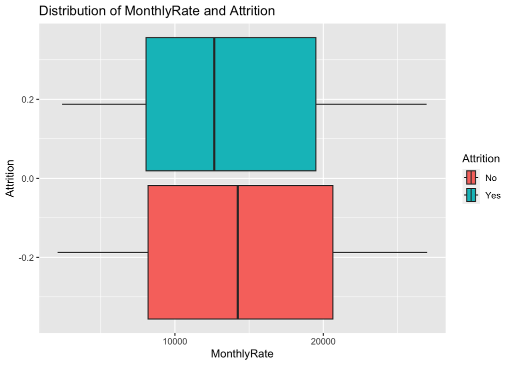

```r
CS2 %>%  ggplot(aes(x = MonthlyRate, fill = Attrition)) + geom_boxplot() + ggtitle("Distribution of MonthlyRate and Attrition") + ylab("Attrition")
```

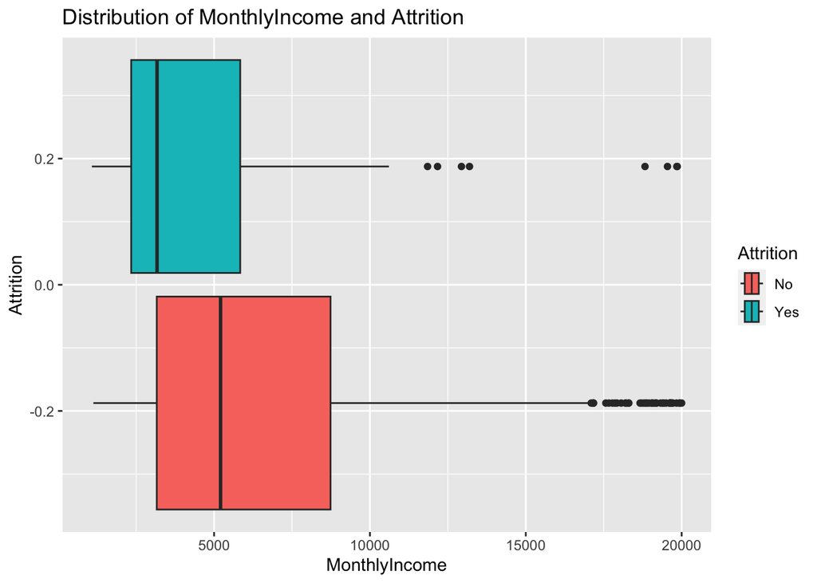

```r
CS2 %>%  ggplot(aes(x = MonthlyIncome, fill = Attrition)) + geom_boxplot() + ggtitle("Distribution of MonthlyIncome and Attrition") + ylab("Attrition")
```

```r
CS2 %>% group_by(Attrition) %>% summarise(median(DailyRate))
```

```
## # A tibble: 2 × 2
##   Attrition `median(DailyRate)`
##   <chr>                   <dbl>
## 1 No                       828.
## 2 Yes                      751
```

```r
CS2 %>% group_by(Attrition) %>% summarise(median(HourlyRate))
```

```
## # A tibble: 2 × 2
##   Attrition `median(HourlyRate)`
##   <chr>                    <dbl>
## 1 No                        64.5
## 2 Yes                       68.5
```

```r
CS2 %>% group_by(Attrition) %>% summarise(median(MonthlyRate))
```

```
## # A tibble: 2 × 2
##   Attrition `median(MonthlyRate)`
##   <chr>                     <dbl>
## 1 No                       14236.
## 2 Yes                      12651
```

```r
CS2 %>% group_by(Attrition) %>% summarise(median(MonthlyIncome))
```

```
## # A tibble: 2 × 2
##   Attrition `median(MonthlyIncome)`
##   <chr>                       <dbl>
## 1 No                          5208.
## 2 Yes                         3171
```

#Plotting Attrition by YearsSinceLastPromotion

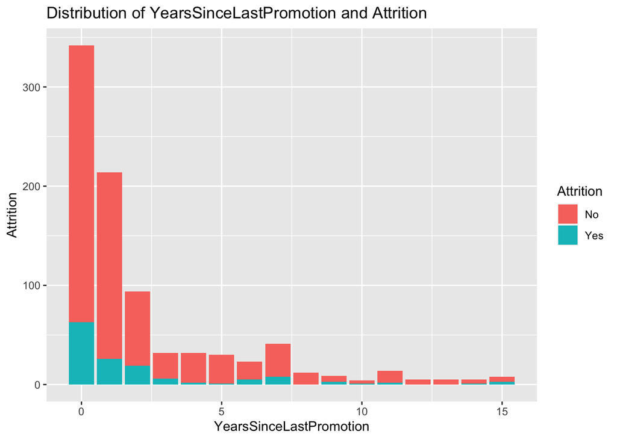

```r
CS2 %>%  ggplot(aes(x = YearsSinceLastPromotion, fill = Attrition)) + geom_bar() + ggtitle("Distribution of YearsSinceLastPromotion and Attrition") + ylab("Attrition")
```

```r
CS2 %>% group_by(Attrition) %>% summarise(mean(YearsSinceLastPromotion))
```

```
## # A tibble: 2 × 2
##   Attrition `mean(YearsSinceLastPromotion)`
##   <chr>                               <dbl>
## 1 No                                   2.18
## 2 Yes                                  2.14
```

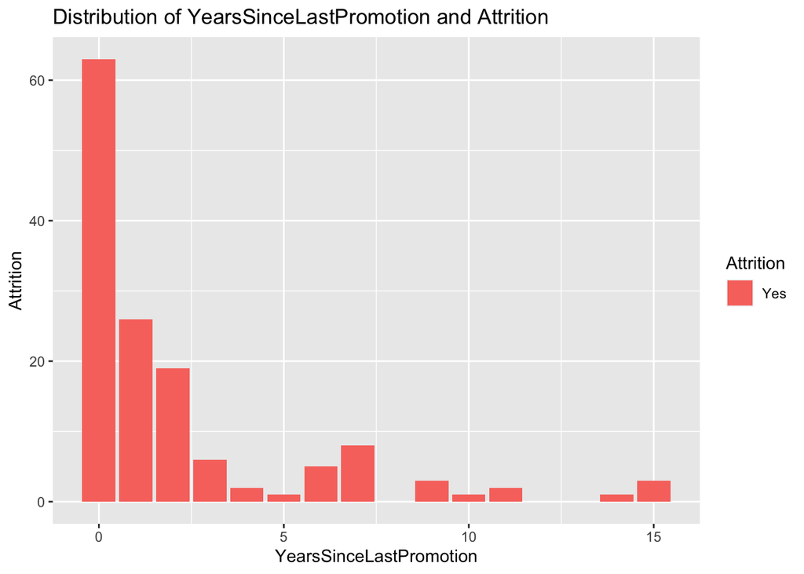

```r
CS2 %>% filter(Attrition == "Yes") %>%ggplot(aes(x = YearsSinceLastPromotion, fill = Attrition)) + geom_bar() + ggtitle("Distribution of YearsSinceLastPromotion and Attrition") + ylab("Attrition")
```

#One would think that if an employee is not promoted for a long time, then they would leave, but the plot does not suggest that relation

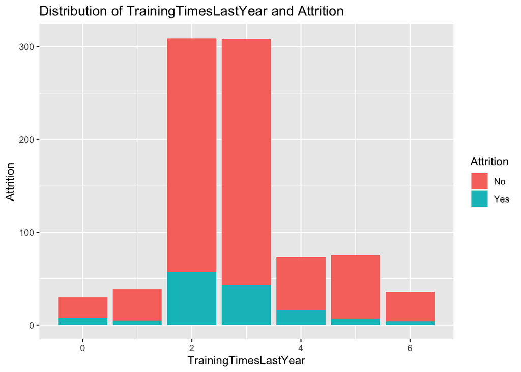

```r
CS2 %>%  ggplot(aes(x = TrainingTimesLastYear, fill = Attrition)) + geom_bar() + ggtitle("Distribution of TrainingTimesLastYear and Attrition") + ylab("Attrition")
```

```r
CS2 %>% group_by(Attrition) %>% summarise(mean(TrainingTimesLastYear))
```

```
## # A tibble: 2 × 2
##   Attrition `mean(TrainingTimesLastYear)`
##   <chr>                             <dbl>
## 1 No                                 2.87
## 2 Yes                                2.65
```

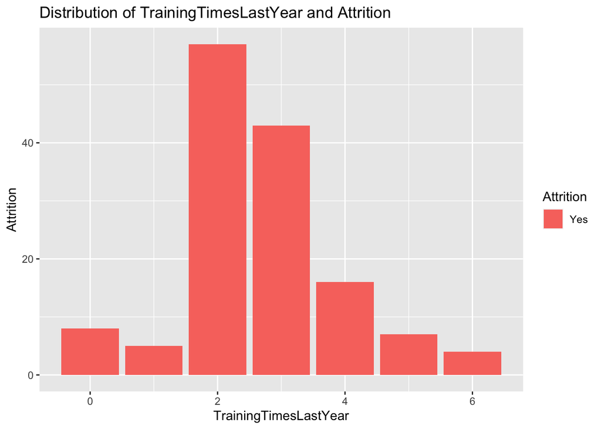

```r
CS2 %>% filter(Attrition == "Yes") %>%ggplot(aes(x = TrainingTimesLastYear, fill = Attrition)) + geom_bar() + ggtitle("Distribution of TrainingTimesLastYear and Attrition") + ylab("Attrition")
```

#Plot does not suggest that Training Time influences Attrition

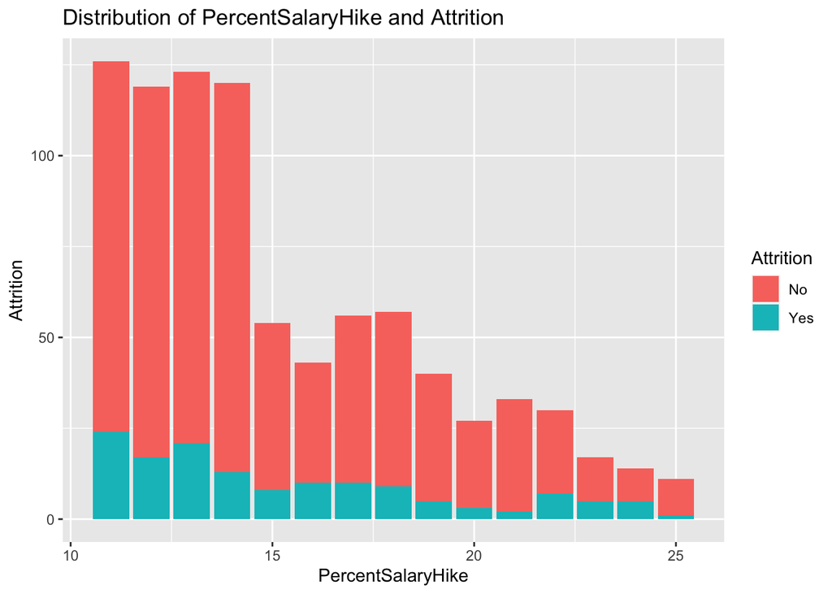

```r
CS2 %>% ggplot(aes(x = PercentSalaryHike, fill = Attrition)) + geom_bar() + ggtitle("Distribution of PercentSalaryHike and Attrition") + ylab("Attrition")
```

```r
CS2 %>% group_by(Attrition) %>% summarise(median(PercentSalaryHike))
```

```
## # A tibble: 2 × 2
##   Attrition `median(PercentSalaryHike)`
##   <chr>                           <dbl>
## 1 No                                 14
## 2 Yes                                14
```

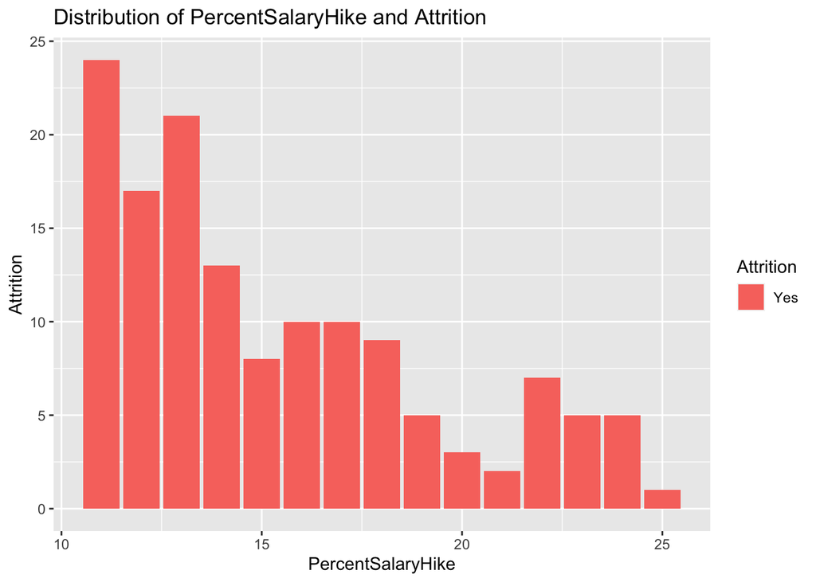

```r
CS2 %>% filter(Attrition == "Yes") %>% ggplot(aes(x = PercentSalaryHike, fill = Attrition)) + geom_bar() + ggtitle("Distribution of PercentSalaryHike and Attrition") + ylab("Attrition")
```

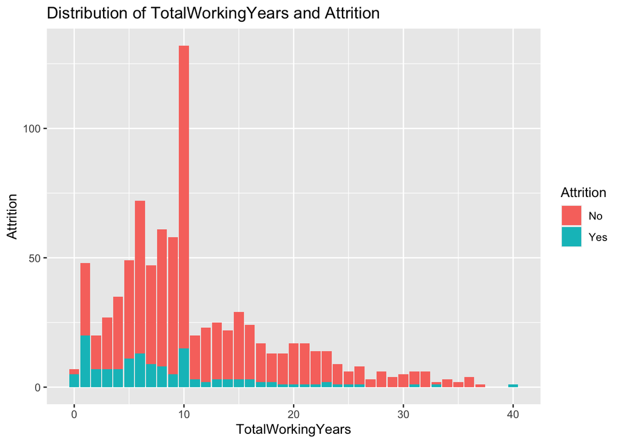

```r
CS2 %>% ggplot(aes(x = TotalWorkingYears, fill = Attrition)) + geom_bar() + ggtitle("Distribution of TotalWorkingYears and Attrition") + ylab("Attrition")
```

```r
CS2 %>% group_by(Attrition) %>% summarise(median(TotalWorkingYears))
```

```
## # A tibble: 2 × 2
##   Attrition `median(TotalWorkingYears)`
##   <chr>                           <dbl>
## 1 No                               10
## 2 Yes                               6.5
```

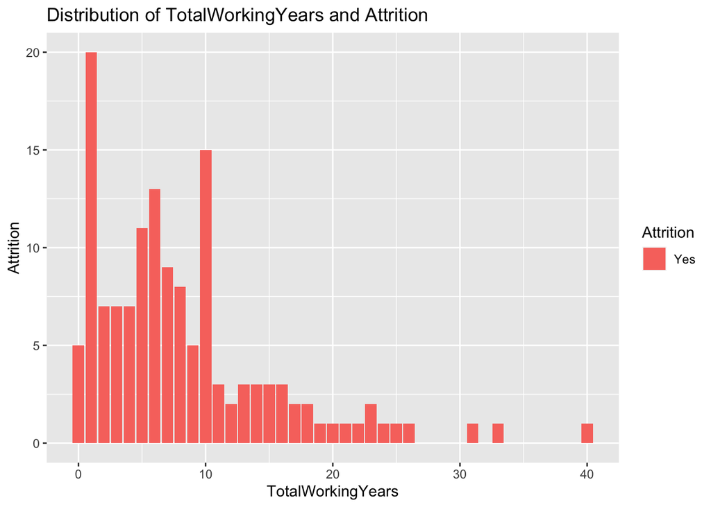

```r
CS2 %>% filter(Attrition == "Yes") %>% ggplot(aes(x = TotalWorkingYears, fill = Attrition)) + geom_bar() + ggtitle("Distribution of TotalWorkingYears and Attrition") + ylab("Attrition")
```

#Plot does suggest the employeers with more Total Working Years are less likely to quit

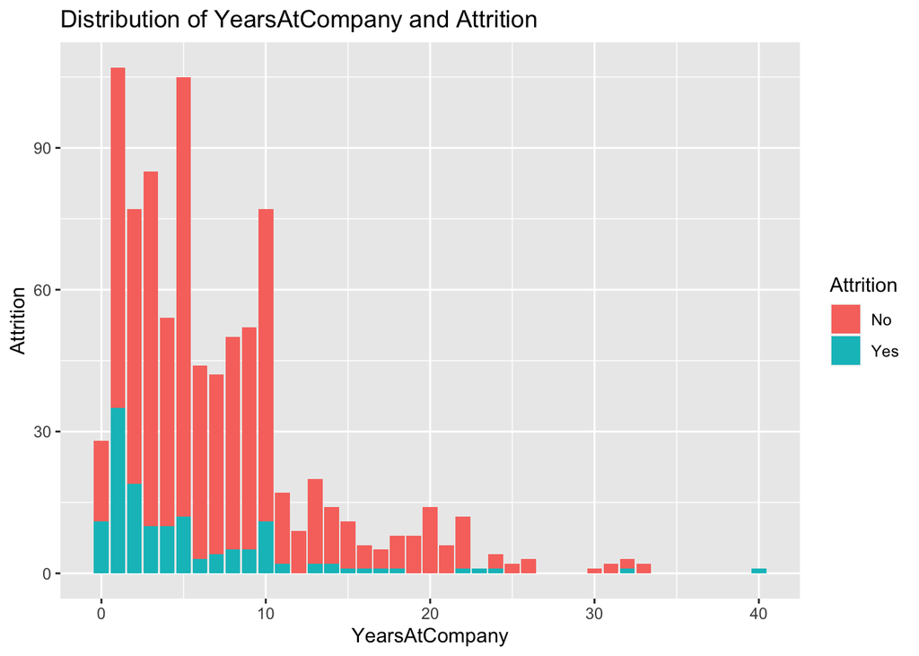

```r
CS2 %>% ggplot(aes(x = YearsAtCompany, fill = Attrition)) + geom_bar() + ggtitle("Distribution of YearsAtCompany and Attrition") + ylab("Attrition")
```

```r
CS2 %>% group_by(Attrition) %>% summarise(median(YearsAtCompany))
```

```
## # A tibble: 2 × 2
##   Attrition `median(YearsAtCompany)`
##   <chr>                        <dbl>
## 1 No                               6
## 2 Yes                              3
```

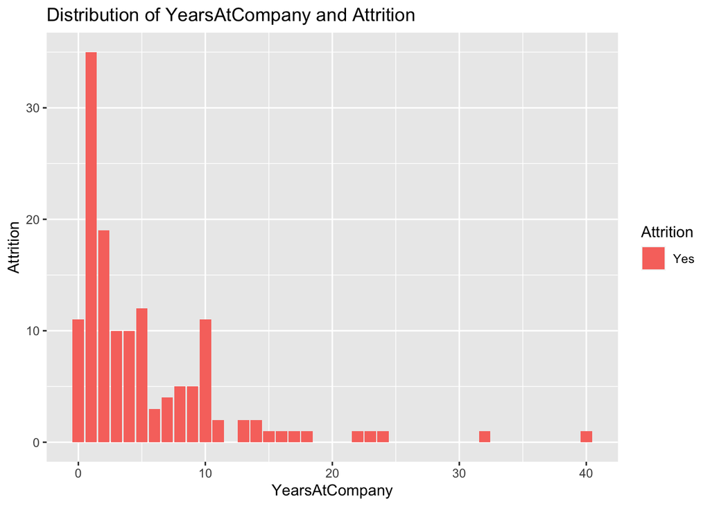

```r
CS2 %>% filter(Attrition == "Yes") %>% ggplot(aes(x = YearsAtCompany, fill = Attrition)) + geom_bar() + ggtitle("Distribution of YearsAtCompany and Attrition") + ylab("Attrition")
```

#Plot does suggest the employeers with more Years at the Compaany are less likely to quit

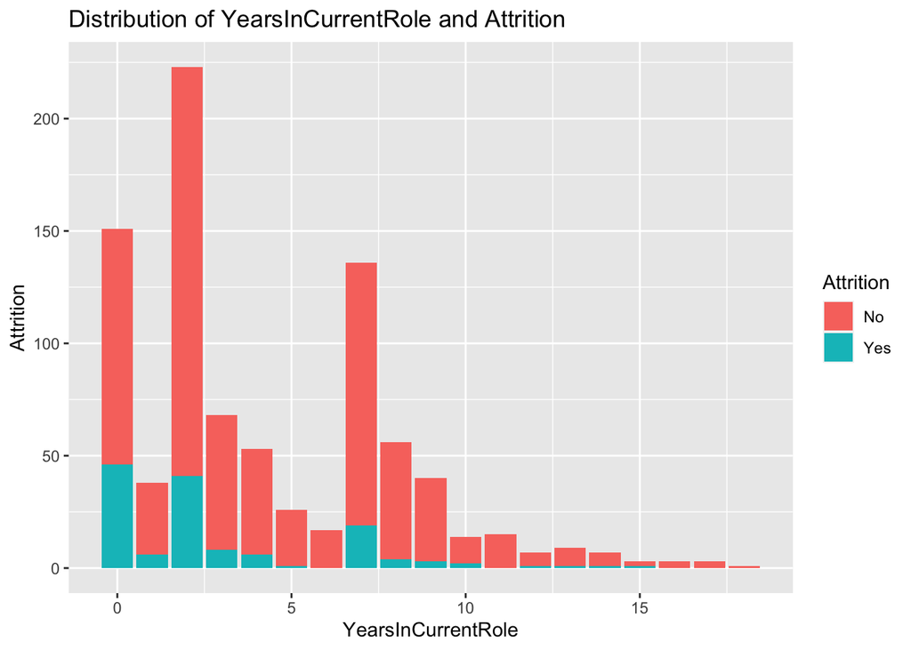

```r
CS2 %>% ggplot(aes(x = YearsInCurrentRole, fill = Attrition)) + geom_bar() + ggtitle("Distribution of YearsInCurrentRole and Attrition") + ylab("Attrition")
```

```r
CS2 %>% group_by(Attrition) %>% summarise(median(YearsInCurrentRole))
```

```
## # A tibble: 2 × 2
##   Attrition `median(YearsInCurrentRole)`
##   <chr>                            <dbl>
## 1 No                                   3
## 2 Yes                                  2
```

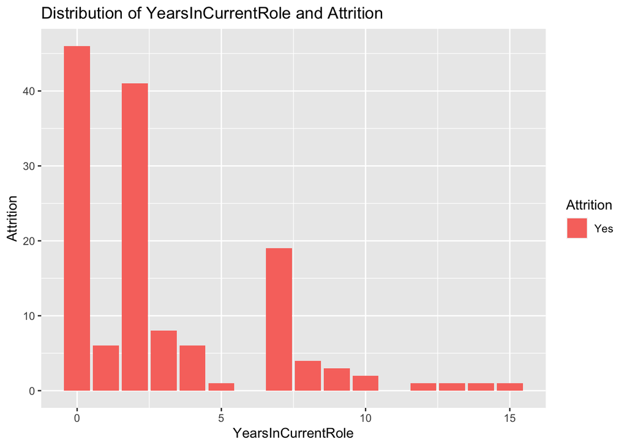

```r
CS2 %>% filter(Attrition == "Yes") %>% ggplot(aes(x = YearsInCurrentRole, fill = Attrition)) + geom_bar() + ggtitle("Distribution of YearsInCurrentRole and Attrition") + ylab("Attrition")
```

#Plot does suggest the employeers with less Years in current role are more likely to quit

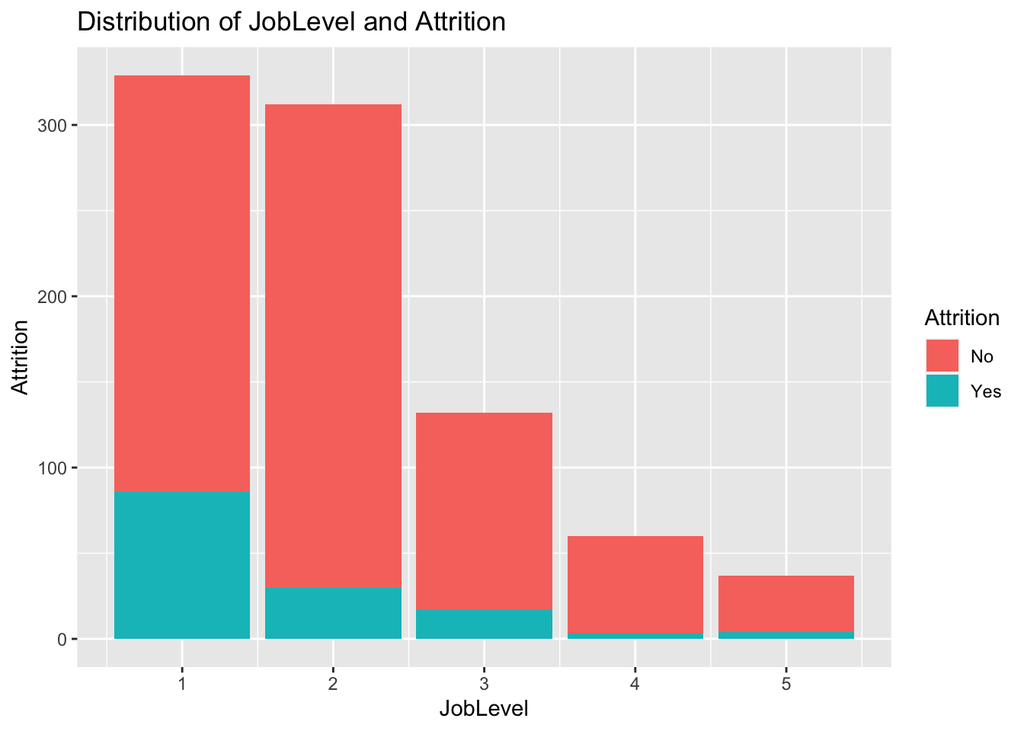

```r
CS2 %>% ggplot(aes(x = JobLevel, fill = Attrition)) + geom_bar() + ggtitle("Distribution of JobLevel and Attrition") + ylab("Attrition")
```

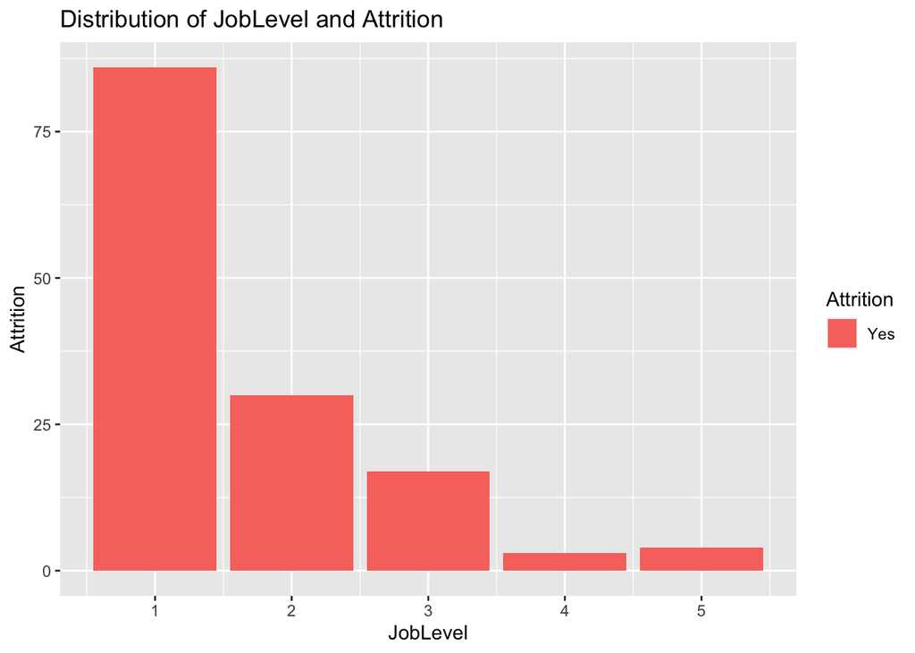

```r
CS2 %>% filter(Attrition == "Yes") %>% ggplot(aes(x = JobLevel, fill = Attrition)) + geom_bar() + ggtitle("Distribution of JobLevel and Attrition") + ylab("Attrition")
```

#Plot does suggest the employees at Lower Job Level are more likely to quit

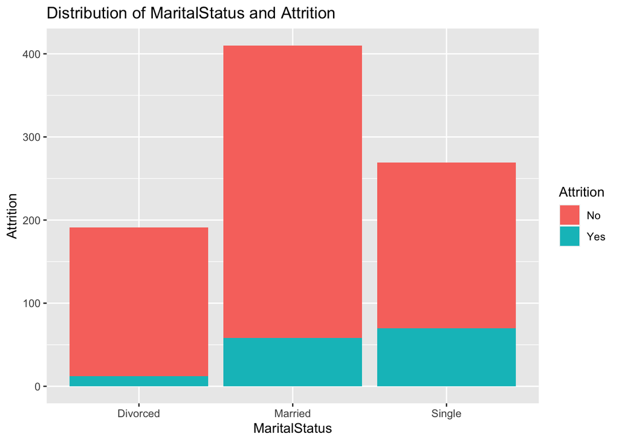

```r
CS2 %>% ggplot(aes(x = MaritalStatus, fill = Attrition)) + geom_bar() + ggtitle("Distribution of MaritalStatus and Attrition") + ylab("Attrition")
```

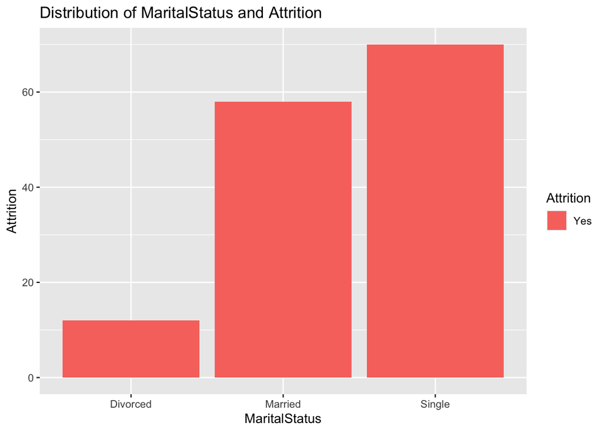

```r
CS2 %>% filter(Attrition == "Yes") %>% ggplot(aes(x = MaritalStatus, fill = Attrition)) + geom_bar() + ggtitle("Distribution of MaritalStatus and Attrition") + ylab("Attrition")
```

#Plot does suggest the single employees are slightly more likely to quit

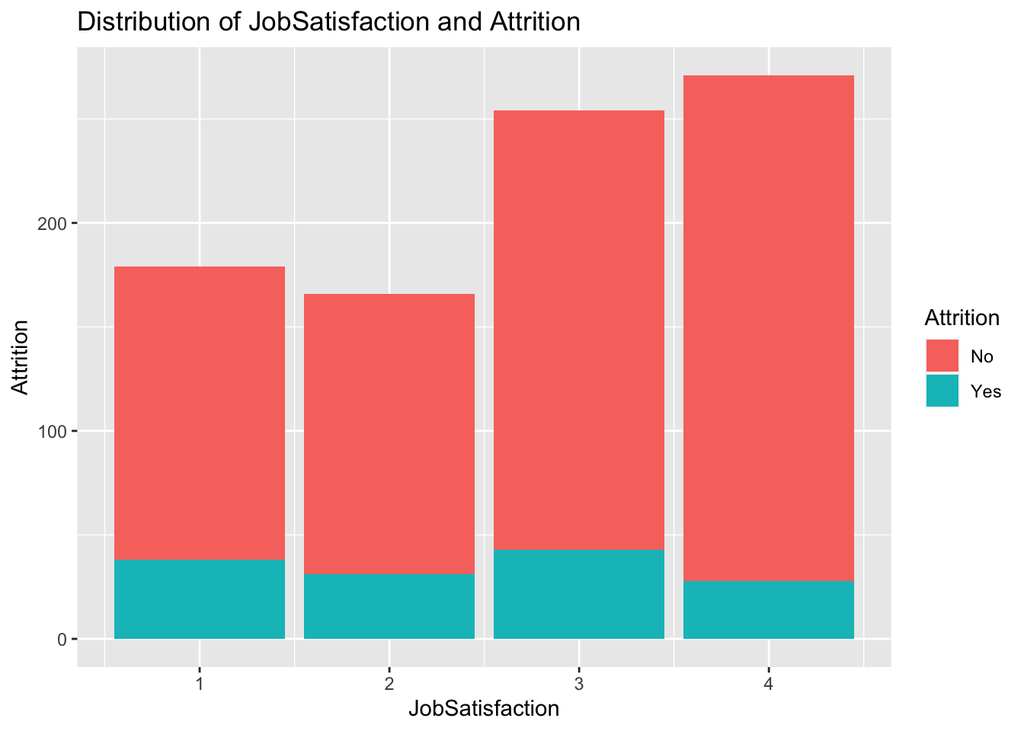

```r
CS2 %>% ggplot(aes(x = JobSatisfaction, fill = Attrition)) + geom_bar() + ggtitle("Distribution of JobSatisfaction and Attrition") + ylab("Attrition")
```

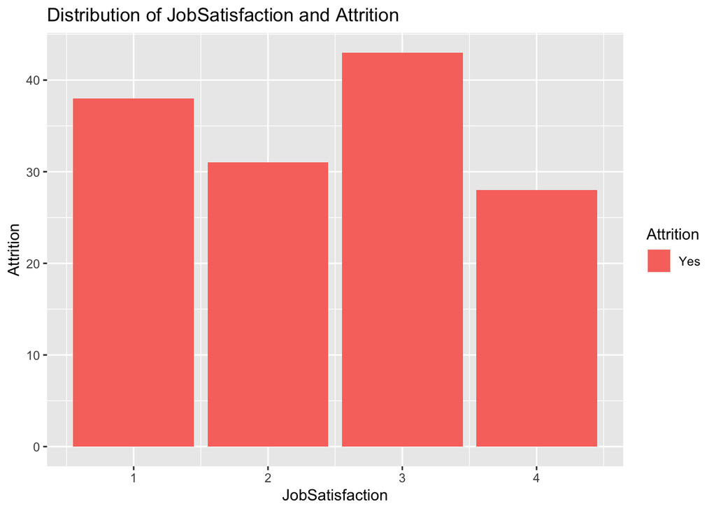

```r
CS2 %>% filter(Attrition == "Yes") %>% ggplot(aes(x = JobSatisfaction, fill = Attrition)) + geom_bar() + ggtitle("Distribution of JobSatisfaction and Attrition") + ylab("Attrition")
```

#Plot does suggest the level of Job Satisfaction is not playing a significant role in Attrition

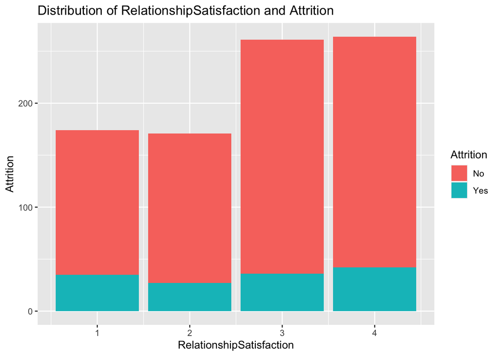

```r
CS2 %>% ggplot(aes(x = RelationshipSatisfaction, fill = Attrition)) + geom_bar() + ggtitle("Distribution of RelationshipSatisfaction and Attrition") + ylab("Attrition")
```

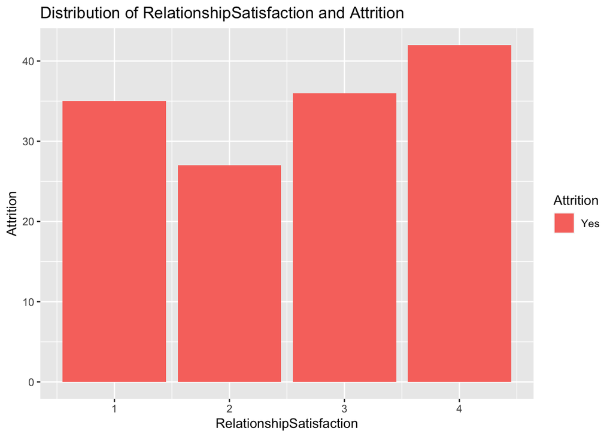

```r
CS2 %>% filter(Attrition == "Yes") %>% ggplot(aes(x = RelationshipSatisfaction, fill = Attrition)) + geom_bar() + ggtitle("Distribution of RelationshipSatisfaction and Attrition") + ylab("Attrition")
```

#Plot does suggest the level of RelationshipSatisfaction is not playing a significant role in Attrition

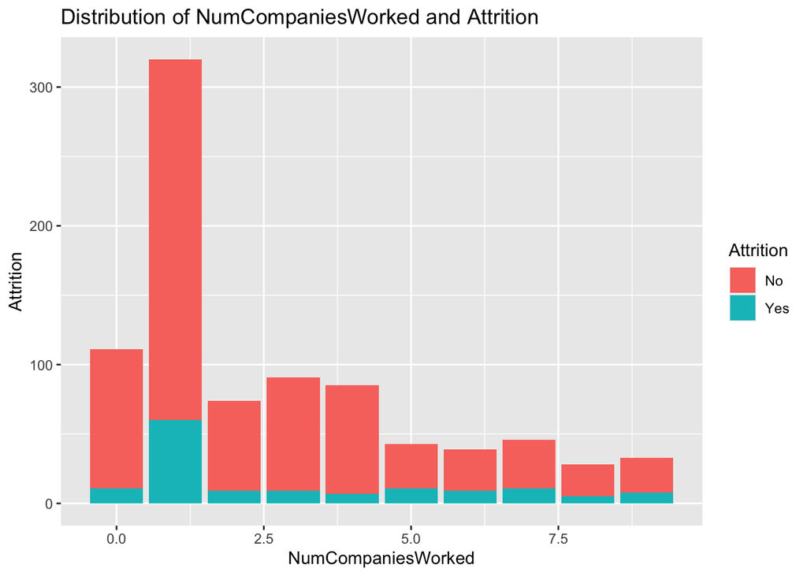

```r
CS2 %>% ggplot(aes(x = NumCompaniesWorked, fill = Attrition)) + geom_bar() + ggtitle("Distribution of NumCompaniesWorked and Attrition") + ylab("Attrition")
```

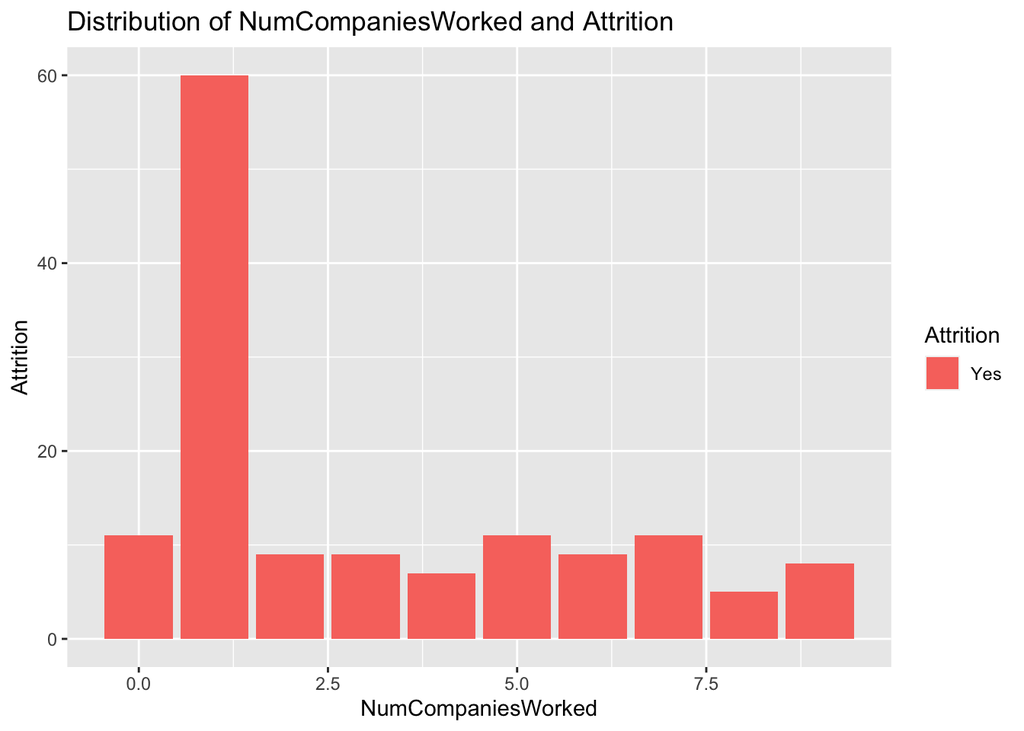

```r
CS2 %>% filter(Attrition == "Yes") %>% ggplot(aes(x = NumCompaniesWorked, fill = Attrition)) + geom_bar() + ggtitle("Distribution of NumCompaniesWorked and Attrition") + ylab("Attrition")
```

#Plot does suggest the level of Num of Companies worked is not playing a significant role in Attrition